# Tarea 1

### Integrantes del equipo

- David Salvador Preciado Márquez
- Britny Brito Juárez
- América Itzel Vicente García

# Inmuebles

```r
library(readxl)
BD_Inmuebles_1 <- read_excel("BD-Inmuebles-1.xls",
    col_types = c("text", "text", "text",
        "numeric", "numeric", "date", "text",
        "text"))
BD_Inmuebles_1 <- data.frame(BD_Inmuebles_1)
```

### Clasificación de variables

- Categóricas
  - Tipo de inmueble (nominal)
  - Operación (nominal)
  - Provincia (nominal)
  - Fecha venta (ordinal)
  - Vendedor (nominal)
  - Satisfacción (ordinal)
- Numéricas
  - Superficie (de razón)
  - Precio Venta (de razón)

### Análisis de variable superficie

```r
# Medidas de tendencia central
# Media
Superficie_media <- mean(BD_Inmuebles_1$Superficie)
# Mediana
Superficie_mediana <- median(BD_Inmuebles_1$Superficie)
# Moda
# Dado que tratamos con una variable numérica continua, no tiene sentido poner la moda
# Percentiles
Superficie_percentiles <- quantile(BD_Inmuebles_1$Superficie)

#Medidas de dispersión
# Varianza
Superficie_var <- var(BD_Inmuebles_1$Superficie)
# Desviación estándar
Superficie_std <- sd(BD_Inmuebles_1$Superficie)
# Rango
Superficie_rango <- max(BD_Inmuebles_1$Superficie) - min(BD_Inmuebles_1$Superficie)
# Rango intercuartílico
Superficie_rangointer <- quantile(BD_Inmuebles_1$Superficie, 0.75) - quantile(BD_Inmuebles_1$Superficie, 0.25)
# Coeficiente de variación
Superficie_cv <- (Superficie_std / Superficie_media) * 100

# Percentil 0.76 de los registros del 2005
library(dplyr)
BD_Inmuebles_1_2005 <- BD_Inmuebles_1 %>% filter(between(Fecha.Venta, as.POSIXct('2005-01-01'), as.POSIXct('2005-12-31')))
Superficie_percentil76 <- quantile(BD_Inmuebles_1_2005$Superficie, 0.76)
```

Por lo tanto, las medidas de tendencia central son:

- Media: 134.030039735099
- Mediana: 139.3
- Moda: la omitimos porque estamos trabajando con una variable numérica continua.
- Percentiles (0%, 25%, 50%, 75%, 100%): 51.7, 98.42, 139.3, 169.245, 213.91

Las de dispersión son:

- Varianza: 1504.04459853953
- Desviación estándar: 38.7820138535834
- Rango: 162.21
- Rango intercuartílico: 70.825
- Coeficiente de variación: 28.9353147475247

Además, el percentil 0.76 de los registros correspondientes a ventas del año 2005 es 169.25.

### Año con mayor ingreso

```r
BD_Inmuebles_1_Yr <- filter(BD_Inmuebles_1, Operación == "Alquiler")
BD_Inmuebles_1_Yr$Fecha.Venta <- format(as.POSIXct(BD_Inmuebles_1_Yr$Fecha.Venta), "%Y")
BD_Inmuebles_1_Ingresos_Anuales <- BD_Inmuebles_1_Yr %>% group_by(Fecha.Venta) %>% summarise(Ventas = sum(Precio.Venta))
Max_Yr <- BD_Inmuebles_1_Ingresos_Anuales[which.max(BD_Inmuebles_1_Ingresos_Anuales$Ventas),1]
```

Por lo tanto el año con mayor ingreso fue 2006.

### Boxplot Precio-Venta

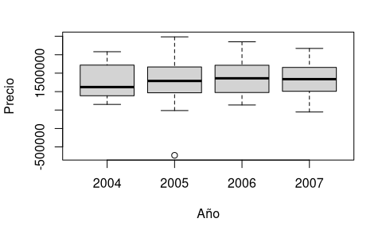

```r
boxplot(data = BD_Inmuebles_1_Yr, Precio.Venta ~ Fecha.Venta, xlab = "Año", ylab = "Precio")
```

Por el boxplot parece que en el año 2005 hubo algunas ventas un poco mayores. En general la media de ventas en cada año se mantiene relativamente estable, excepto en el año 2004 donde la media parece ser ligeramente menor.

### Coeficiente de correlación

```r
BD_Inmuebles_1_Venta <- filter(BD_Inmuebles_1, Operación == "Venta")
BD_Inmuebles_1_Alquiler <- filter(BD_Inmuebles_1, Operación == "Alquiler")
Cor_Superficie_Precio_Venta <- cor(BD_Inmuebles_1_Venta$Superficie, BD_Inmuebles_1_Venta$Precio.Venta)
Cor_Superficie_Precio_Alquiler <- cor(BD_Inmuebles_1_Alquiler$Superficie, BD_Inmuebles_1_Alquiler$Precio.Venta)
```

Por lo tanto, el coeficiente de correlación entre las variables Superficie y Precio-Venta es de 0.858499177201533 en el caso de las operaciones de venta y 0.833889924381824 en el caso de las operaciones de alquiler.

Considerando que el valor del coeficiente de correlación se mueve entre -1 y 1, diría que los valores obtenidos nos dicen que existe una correlación positiva importante entre las variables (cuando una crece, la otra también).

# Fútbol

```r
#importamos los datos
library(readr)
Futbol <- read.csv("Futbol.csv")
Futbol <- data.frame(Futbol)


#Manejamos los NA de los datos
sum(is.na(Futbol))
Futbol <- na.omit(Futbol)
```

### Clasificación de variables

- Categóricas
  - Any (ordinal)
  - Jornada (ordinal)
  - Partit.ID (ordinal)
  - Data (ordinal)
  - Local (nominal)
  - Visitant (nominal)
- Numéricas
  - GL (absoluta)
  - GV (absoluta)

### Análisis de variable goles

```r
#Agregamos variable número total de goles
Futbol$`Numero total de goles` <- Futbol$GL + Futbol$GV

# Medidas de tendencia central
# Media
Total_goles_media <- mean(Futbol$`Numero total de goles`)
# Mediana
Total_goles_mediana <- median(Futbol$`Numero total de goles`)
# Moda
moda <- function(x) {
  return(as.numeric(names(which.max(table(x)))))
}
Total_goles_moda <- moda(Futbol$`Numero total de goles`)
# Percentiles
Total_goles_percentiles <- quantile(Futbol$`Numero total de goles`)

#Medidas de dispersión
# Varianza
Total_goles_var <- var(Futbol$`Numero total de goles`)

# Desviación estándar
Total_goles_std <- sd(Futbol$`Numero total de goles`)
# Rango
Total_goles_rango <- max(Futbol$`Numero total de goles`) - min(Futbol$`Numero total de goles`)
# Rango intercuartílico
Total_goles_rangointer <- quantile(Futbol$`Numero total de goles`, 0.75) - quantile(Futbol$`Numero total de goles`, 0.25)
# Coeficiente de variación
Total_goles_cv <- (Total_goles_std / Total_goles_media) * 100

# Percentil 0.95
library(dplyr)
Total_goles_percentil95 <- quantile(Futbol$`Numero total de goles`, 0.95)
```

Por lo tanto, las medidas de tendencia central son:

- Media: 2.53690503564038
- Mediana: 2
- Moda: 2
- Percentiles (0%, 25%, 50%, 75%, 100%): 0, 1, 2, 4, 11

Las de dispersión son:

- Varianza: 2.7428600073082
- Desviación estándar: 1.65615820720975
- Rango: 11
- Rango intercuartílico: 3
- Coeficiente de variación: 65.282625243861

Además, el percentil 0.95 es 6.

El histograma sería

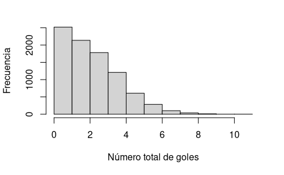

```r
hist(Futbol$`Numero total de goles`, main = paste(""),xlab = "Número total de goles", ylab = "Frecuencia")
```

Lo cual nos muestra que los partidos sin goles son mucho más comunes, y se van haciendo más infrecuentes mientras más goles ocurren. El boxplot sería

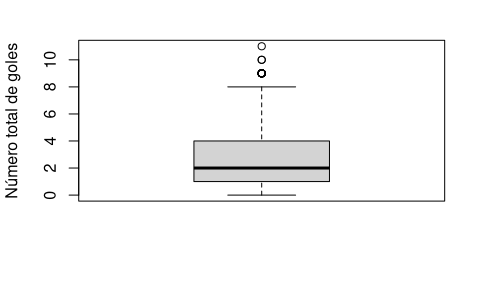

```r
boxplot(Futbol$`Numero total de goles`, ylab = "Número total de goles")
```

Que nos hace evidente que la media de goles es $2$, mientras que tenemos tres outliers con $9$, $10$ y $11$ goles.

### Equipo que más goles anotó y recibió por cada año

```r
#Encontramos cuantos goles anotó y recibió cada equipo como visitante por año de jornada (Any)
visitante <- Futbol %>% group_by(Any, Visitant) %>% summarise(anotadosVisitante = sum(GV), recibidosVisitante = sum(GL))

#Encontramos cuantos goles anotó y recibió cada equipo como local por año de jornada (Any)
local<- Futbol %>% group_by(Any, Local) %>% summarise(anotadosLocal = sum(GL), recibidosLocal = sum(GV))

#Juntamos en un solo data frame la información previamente obtenida sobre goles anotados y recibidos
goles <- visitante
goles$anotadosLocal <- local$anotadosLocal
goles$recibidosLocal <- local$recibidosLocal

#Encontramos cuantos goles anotó y recibió cada equipo en total por año de jornada (Any)
golesT <- goles  %>% group_by(Any, Visitant) %>% summarise(recibidos = recibidosLocal + recibidosVisitante,
                             anotados = anotadosVisitante + anotadosLocal)

#Encontramos el índice de los equipos que anotaron y recibieron más goles por año de jornada (Any)
goles_Indice <- golesT  %>% group_by(Any) %>% summarise(masRecibidos = which.max(recibidos), masAnotados = which.max(anotados))

#Encontramos los equipos que más anotaron y recibieron goles por año de jornada (Any)
goles_Maximo <- data.frame(Any = goles_Indice$Any, masAnotados = golesT$Visitant[goles_Indice$masAnotados],
                           masRecibidos = golesT$Visitant[goles_Indice$masRecibidos])
```

Por lo tanto, por cada año de temporada obtenemos la siguiente tabla

```r
goles_Maximo
```

| Any | masAnotados | masRecibidos |
| --- | --- | --- |
| 1 | F.C. Barcelona | R. Valladolid D. |
| 2 | F.C. Barcelona | Real Murcia C.F. |
| 3 | Real Madrid C.F. | R.C.D. Espanyol |
| 4 | Real Madrid C.F. | Valencia C.F. |
| 5 | Real S. de Gijón | At. de Madrid |
| 6 | Real S. de Gijón | R. Valladolid D. |
| 7 | Real Sociedad | Real S. de Gijón |
| 8 | R. Zaragoza C.D. | Real Murcia C.F. |
| 9 | R. Zaragoza C.D. | Real Madrid C.F. |
| 10 | R. Zaragoza C.D. | R. Valladolid D. |

[output cut: 13 more lines]

### Boxplot de goles por año

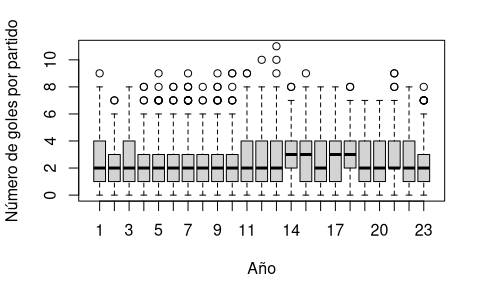

```r
boxplot(data = Futbol, `Numero total de goles` ~ Any, xlab = "Año", ylab = "Número de goles por partido")
```

En el año 13 el promedio de goles por partido tiende a ser mayor, pues existen más outliers y estos se encuentran más elevados, y sabemos que estos afectan de gran madera al promedio de ese año.

### Coeficiente de correlación entre GL y GV

```r
Cor_Futbol_Goles <- cor(Futbol$GL, Futbol$GV)
```

Por lo tanto el coeficiente de correlación es -0.00199972233559461. Dado que el coeficiente de correlación varía en el intervalo $[-1, 1]$ y obtuvimos uno muy cercano a $0$, podemos decir que no existe ninguna correlación entre las variables (el valor de una no tiene ninguna influencia sobre el valor de la otra).